# Fall 2020 - Math 421 - Midterm

## III. Predictive Models

Continue with the data from part I. Use the follows as the target and input variables:

*Target Variable*: Create the target variable taking value of

- `low` if the total charge of a patient (`tot`) is smaller than the median of the total charge, and
- `high` otherwise.

*Input Variables*:

- “age”,“sex”,“raceethn”,“provider”,“moa”,“mod”,“admtype”,“campus”, ‘los’

```r
colSums(is.na(newdata))
```

```
##      yod pay_ub92      age      sex raceethn provider      moa      yoa
##        0        0        0        0        0        0        0        0
##      mod  admtype  asource      los  service      icu      ccu dispub92
##        0        0        0        0        0        0        0        0
##    payer      drg   trandb   randbg   randbs      orr     anes      seq
##        0        0        0        0        0        0        0        0
##      lab    dtest     ther    blood     phar    other   patcon    bwght
##        0        0        0        0        0        0        0        0
##    total      tot ecodub92     b_wt pt_state diag_adm  ancilar   campus
##        0        0        0        0        0        0        0        0
##   er_fee  er_chrg  er_mode obs_chrg psycchrg
##        0        0        0        0        0
```

```r
newdata$preopday <- NULL
```

```r
summary(newdata$tot)
```

```
##    Min. 1st Qu.  Median    Mean 3rd Qu.    Max.
##       0   13379   21854   34317   36919 3402056
```

```r
newdata$target <- case_when(newdata$tot < 21854 ~ 'low',
                          TRUE ~ 'high')
```

1. Use `filter` function to filter out rows where `raceethn==''` or `admtype==''`. Make sure all the categorical variables are factor, numeric variables are numeric. Set Training : Testing Split = 10 : 90

```r
df3<- select(newdata,age,sex,provider,moa,mod,admtype,campus,los,target)

df3 <- df3 %>% filter(!sex==9)
```

```r
df3 <- df3 %>%
  filter(!( admtype==''|sex==''))
```

```r
df3$sex<-factor(df3$sex)
df3$provider <-factor(df3$provider)
df3$admtype <-factor(df3$admtype)
df3$campus <-factor(df3$campus)
```

```r
library(caret)
set.seed(2020)
splitIndex <- createDataPartition(df3$target, p = 0.1,
                                  list = FALSE)
df3_train <- df3[ splitIndex,]
df3_test <- df3[-splitIndex,]
```

2. Train a decision tree using `rpart`. Plot the decision tree. Plot the variable importance ranked by the tree.

```r
library(rpart)

tree_model <- rpart(target ~ ., data = df3_train,
                 control = rpart.control(maxdepth = 3))
```

```r
library(rattle)
```

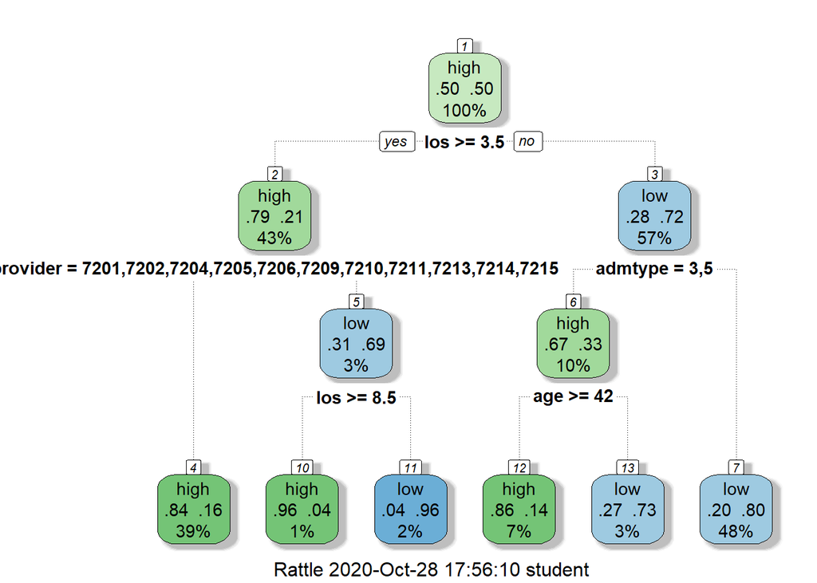

```r
fancyRpartPlot(tree_model)
```

```r
 pred <- predict(tree_model, df3_test,type="class")
 cm <- confusionMatrix(data = pred, reference = factor(df3_test$target), positive = 'high')
 cm$overall[1]
```

```
##  Accuracy
## 0.8143825
```

```r
tree_model$variable.importance
```

```
##       los   admtype  provider       age    campus
## 1850.7805  503.5091  444.0482  222.4528  109.3010
```

3. Using caret for this question. Set `Training Control` to be: Use Cross-Validation of 5 folds across all models. Train & tune at least 3 different models (i.e. three different values for `method=` in the train function of caret). Plot the hyper-parameter tuning plots for each model.

```r
trControl = trainControl(method = "cv",
                         number = 5)

rpart2 <- train(target~., data=df3_train,
                                method = "rpart2",
                                trControl = trControl)
```

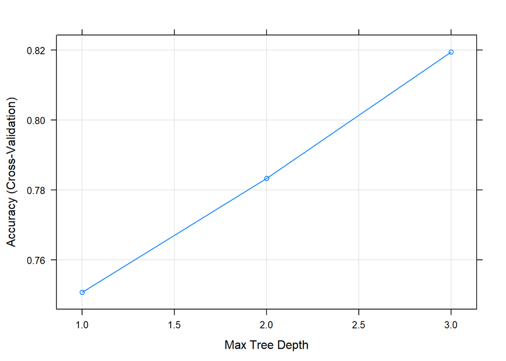

```r
plot(rpart2)
```

```r
tuneGrid = expand.grid(nIter=1:10,method="rf")

trControl = trainControl(method = "cv",
                         number = 5)

adaboost <- train(target~., data=df3_train,
                                method = "adaboost",
                                trControl = trControl,
                                tuneGrid = tuneGrid)
```

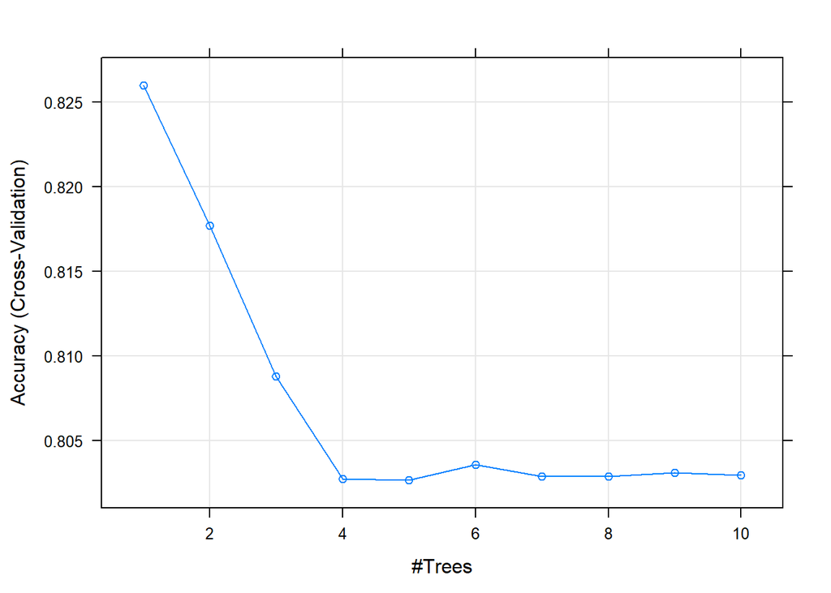

```r
plot(adaboost)
```

```r
trControl=trainControl(method="cv",number=5)

randforest<-train(target~.,data=df3_train,method="rf",trControl=trControl)
```

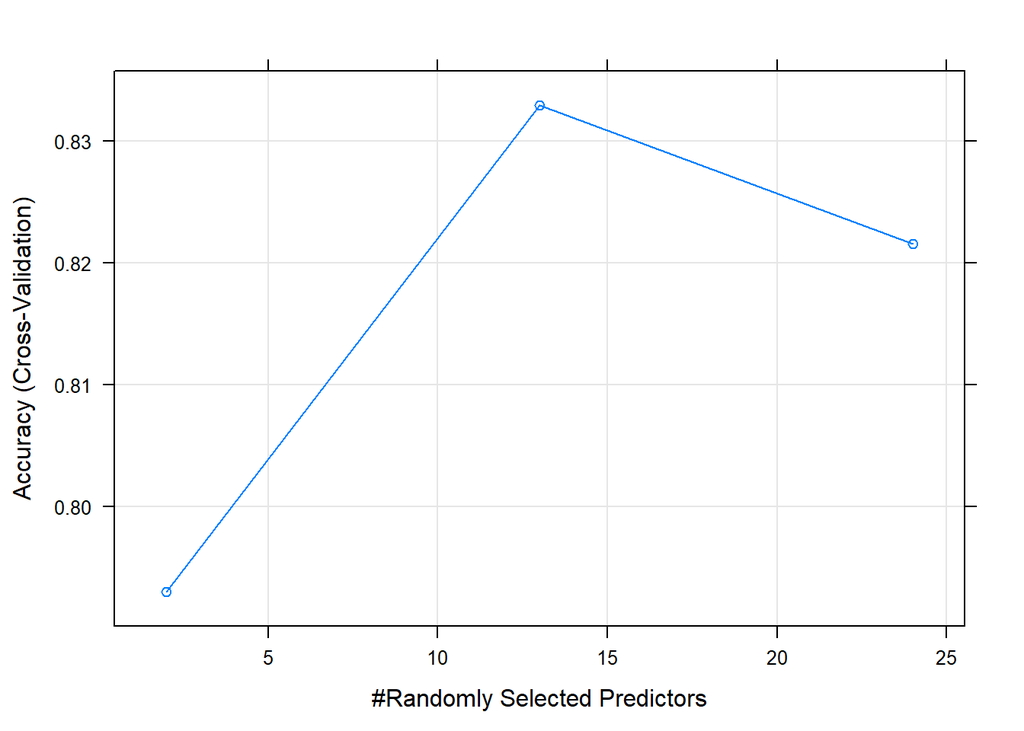

```r
plot(randforest)
```

4. Plot the comparison of the models in 3.

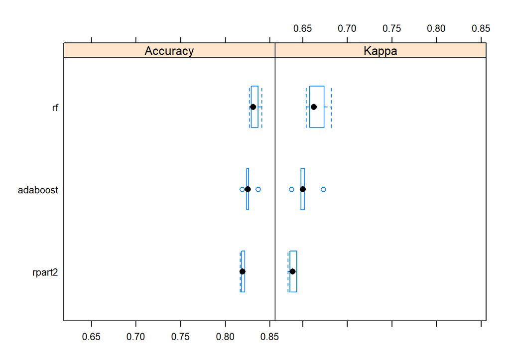

```r
results <- resamples(list(rpart2=rpart2,
                          adaboost=adaboost,
                          rf=randforest
                        ))

bwplot(results)
```

5. What is your final selection for the model? Test the accuracy of your final model on the test data.

```r
pred <- predict(randforest, df3_test)
cm <- confusionMatrix(data = pred, reference = factor(df3_test$target), positive = 'high')
cm$overall[1]
```

```
##  Accuracy
## 0.8261976
```

6. Create another `target` variable (binary), decide the input variables and redo 1 to 5.

```r
colSums(is.na(newdata))
```

```
##      yod pay_ub92      age      sex raceethn provider      moa      yoa
##        0        0        0        0        0        0        0        0
##      mod  admtype  asource      los  service      icu      ccu dispub92
##        0        0        0        0        0        0        0        0
##    payer      drg   trandb   randbg   randbs      orr     anes      seq
##        0        0        0        0        0        0        0        0
##      lab    dtest     ther    blood     phar    other   patcon    bwght
##        0        0        0        0        0        0        0        0
##    total      tot ecodub92     b_wt pt_state diag_adm  ancilar   campus
##        0        0        0        0        0        0        0        0
##   er_fee  er_chrg  er_mode obs_chrg psycchrg   target
##        0        0        0        0        0        0
```

```r
summary(newdata$age)
```

```
##    Min. 1st Qu.  Median    Mean 3rd Qu.    Max.
##    0.00   31.00   56.00   51.15   73.00  110.00
```

```r
newdata$target1 <- case_when(newdata$age < 56 ~ 'young',
                          TRUE ~ 'old')
```

```r
df4<- select(newdata,sex,provider,moa,mod,admtype,campus,los,target1)

df4 <- df4 %>% filter(!sex==9)

df4 <- df4 %>%
  filter(!( admtype==''|sex==''))
```

```r
df4$sex<-factor(df4$sex)
df4$provider <-factor(df4$provider)
df4$admtype <-factor(df4$admtype)
df4$campus <-factor(df4$campus)
```

```r
library(caret)
set.seed(2020)
splitIndex <- createDataPartition(df4$target1, p = 0.1,
                                  list = FALSE)
df4_train <- df4[ splitIndex,]
df4_test <- df4[-splitIndex,]
```

```r
library(rpart)

tree_model1 <- rpart(target1 ~ ., data = df4_train,
                 control = rpart.control(maxdepth = 3))
```

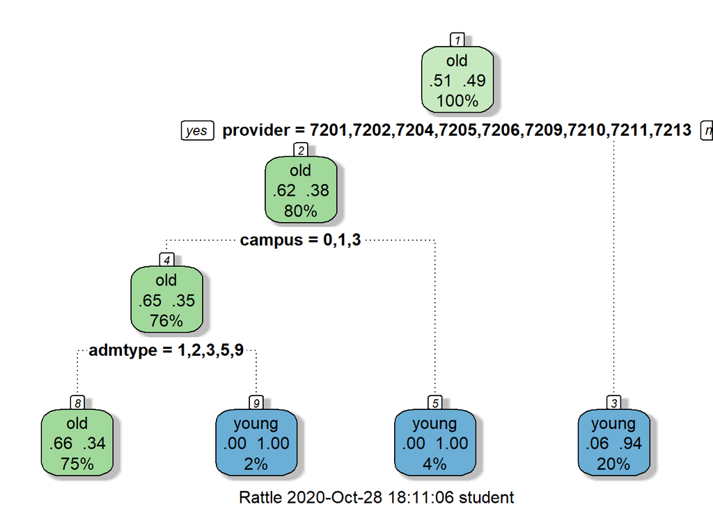

```r
library(rattle)
fancyRpartPlot(tree_model1)
```

```r
 pred <- predict(tree_model1, df4_test,type="class")
 cm <- confusionMatrix(data = pred, reference = factor(df4_test$target1), positive = 'old')
 cm$overall[1]
```

```
##  Accuracy
## 0.7376548
```

```r
tree_model1$variable.importance
```

```
##    provider     admtype      campus         los
## 1298.667215  754.795299  382.319891    7.921721
```

```r
trControl = trainControl(method = "cv",
                         number = 5)

rpart <- train(target1~., data=df4_train,
                                method = "rpart2",
                                trControl = trControl)
```

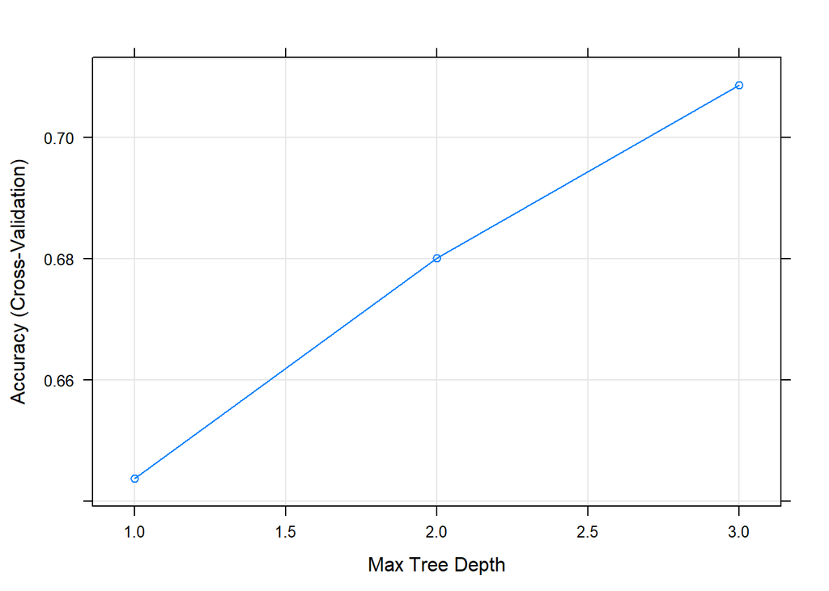

```r
plot(rpart)
```

```r
tuneGrid = expand.grid(nIter=1:10,method="rf")

trControl = trainControl(method = "cv",
                         number = 5)

ab <- train(target1~., data=df4_train,
                                method = "adaboost",
                                trControl = trControl,
                                tuneGrid = tuneGrid)
```

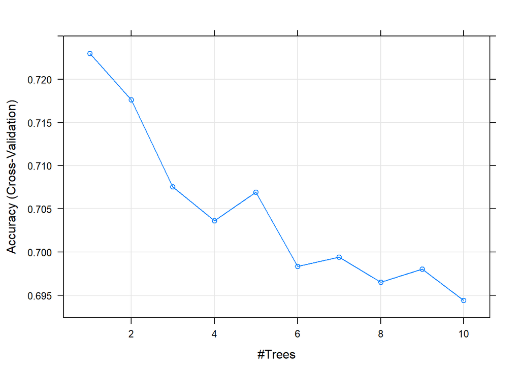

```r
plot(ab)
```

```r
trControl=trainControl(method="cv",number=5)

randforest1<-train(target1~.,data=df4_train,method="rf",trControl=trControl)
```

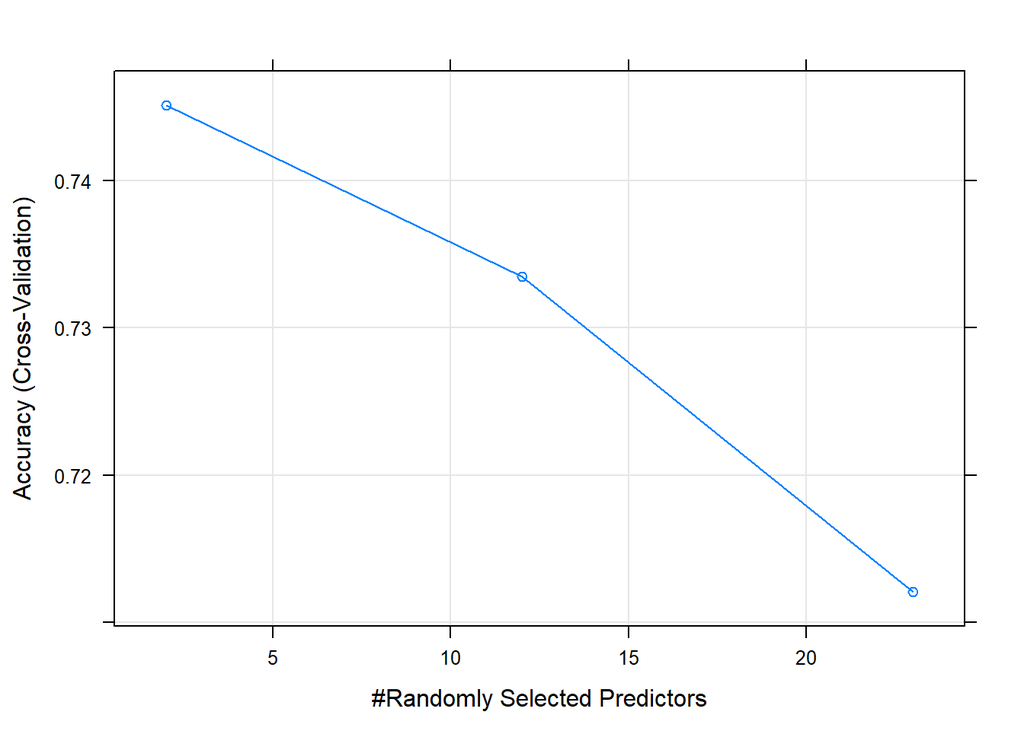

```r
plot(randforest1)
```

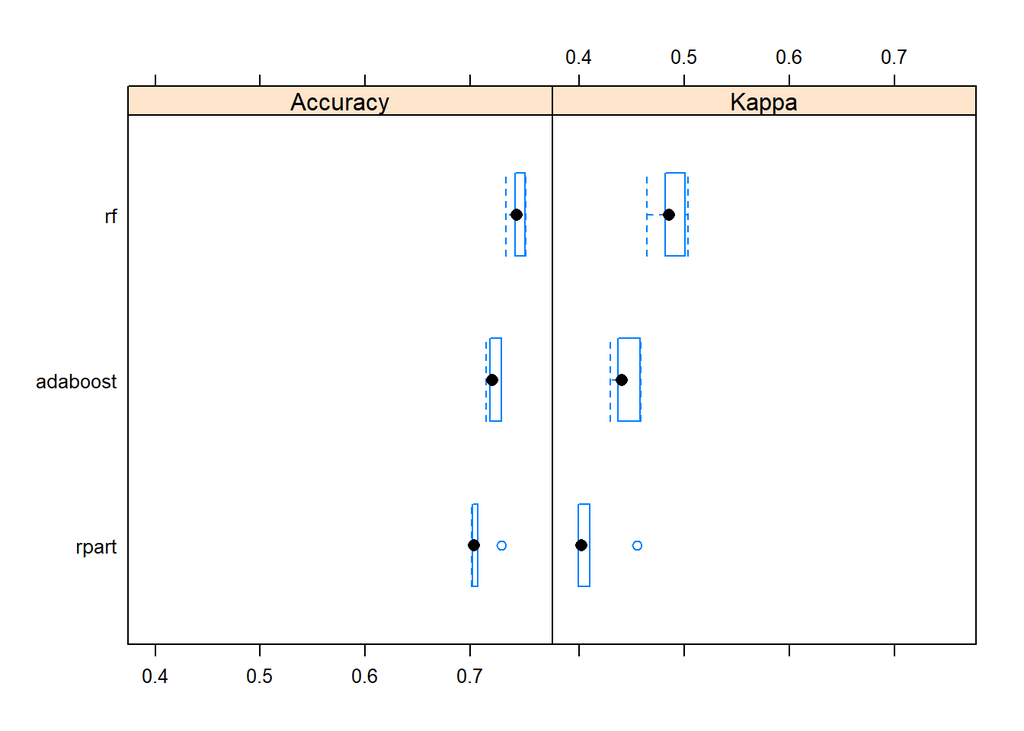

```r
results <- resamples(list(rpart=rpart,
                          adaboost=ab,
                          rf=randforest1
                        ))

bwplot(results)
```

```r
pred <- predict(rpart, df4_test)
cm <- confusionMatrix(data = pred, reference = factor(df4_test$target1), positive = 'old')
cm$overall[1]
```

```
##  Accuracy
## 0.7131714
```

1. Everytime you change the data, you need to retrain the Models
2. Make sure the data for training is the most updated data